# STATS 551 - HW1

Zhen Qin

## 5.

Compute the total number of quizzes for 10000 times. The sample mean and sample variance of these numbers are very close to the theoretical values: mean = 13.5 and variance = 6.75. Thus the results in question 4 are verified.

```r
# set the number of trials
n = 10000

# create a function to generate results
quiz = function(){
  theta = runif(1,0,1)
  rbinom(1,1,theta)
}
total = rep(0,n)
for(i in 1:n){
  for(j in 1:27){
    total[i] = total[i] + quiz()
  }
}

# compute the sample mean and sample variance
mean(total)
```

```
## [1] 13.4686
```

```r
var(total)
```

```
## [1] 6.75689
```

## Exploratory Data Analysis

The dataset is available [here](https://github.com/jensqin/stats551/blob/master/Crabs.dat.txt). There are six variables **crab**(the ID of the observed crab), **y**(stands for the number of crabs near the observation), **weight**, **width**, **color** and **spine**.

### Description

First, I loaded the data using R and extracted 6 rows. It is clear that **y**, **weight** and **width** are numerical variables, while others are categorical variables.

```r
library(knitr)
library(ggplot2)
library(GGally)
# load the data and show 6 rows
crab = read.table("crabs.dat.txt", header = T)
kable(head(crab))
```

| crab | y | weight | width | color | spine |
| --- | --- | --- | --- | --- | --- |
| 1 | 8 | 3.05 | 28.3 | 2 | 3 |
| 2 | 0 | 1.55 | 22.5 | 3 | 3 |
| 3 | 9 | 2.30 | 26.0 | 1 | 1 |
| 4 | 0 | 2.10 | 24.8 | 3 | 3 |
| 5 | 4 | 2.60 | 26.0 | 3 | 3 |
| 6 | 0 | 2.10 | 23.8 | 2 | 3 |

### Quantative Analysis

Second, I used quantative methods to show some properties. The median of **y** is less than the mean of **y**, which suggests **y** may have skewness. **weight** and **width** seem to have normality.

```r
# data summary
crab = crab[,2:6]
crab$color = as.factor(crab$color)
crab$spine = as.factor(crab$spine)
kable(summary(crab))
```

|  | y | weight | width | color | spine |
| --- | --- | --- | --- | --- | --- |
|  | Min. : 0.000 | Min. :1.200 | Min. :21.0 | 1:12 | 1: 37 |
|  | 1st Qu.: 0.000 | 1st Qu.:2.000 | 1st Qu.:24.9 | 2:95 | 2: 15 |
|  | Median : 2.000 | Median :2.350 | Median :26.1 | 3:44 | 3:121 |
|  | Mean : 2.919 | Mean :2.437 | Mean :26.3 | 4:22 | NA |
|  | 3rd Qu.: 5.000 | 3rd Qu.:2.850 | 3rd Qu.:27.7 | NA | NA |
|  | Max. :15.000 | Max. :5.200 | Max. :33.5 | NA | NA |

Then I calculated the correlation matrix of numerical variables. It is worthwhile to note that the correlation of **weight** and **width** is big. Maybe they have colinearity.

```r
# correlation matrix of numerical variables
kable(cor(crab[1:3]))
```

|  | y | weight | width |
| --- | --- | --- | --- |
| y | 1.0000000 | 0.3692474 | 0.3398903 |
| weight | 0.3692474 | 1.0000000 | 0.8868715 |
| width | 0.3398903 | 0.8868715 | 1.0000000 |

### Graphic Analysis

Third, I used graphic methods to explore.

The scatter plot matrix shows pairwise relationship of variables. This plot verifies the guess of quantative analysis.

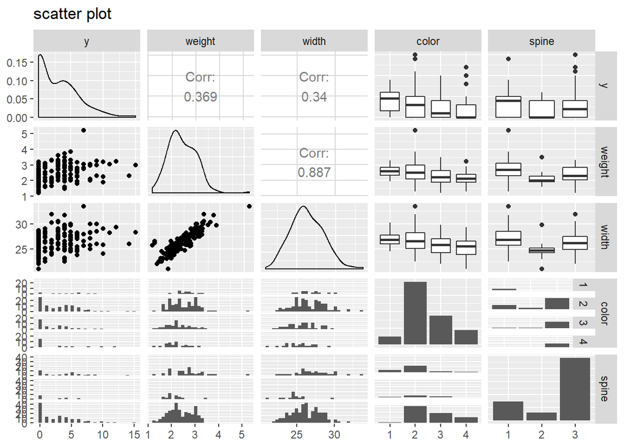

```r
# scatter plot matrix
ggpairs(crab) + ggtitle("scatter plot")
```

The histogram of **y** shows there are many 0s in **y**, so I cannot use any model that assumes **y** has normality. This may be a potential difficult feature of the data.

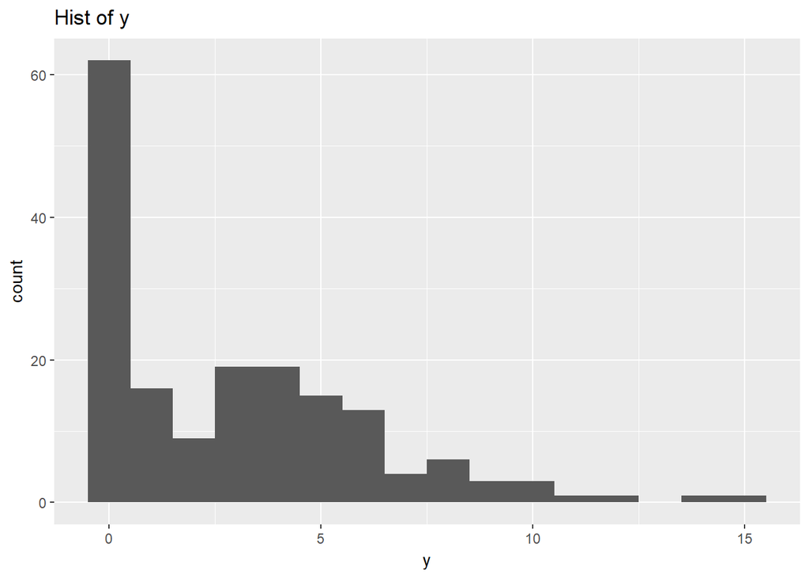

```r
# histogram of y
ggplot(data = crab) + geom_histogram(aes(x = y), binwidth = 1) + ggtitle('Hist of y')
```

The regression line in the following plot has good fit, so these varibles have colinearity.

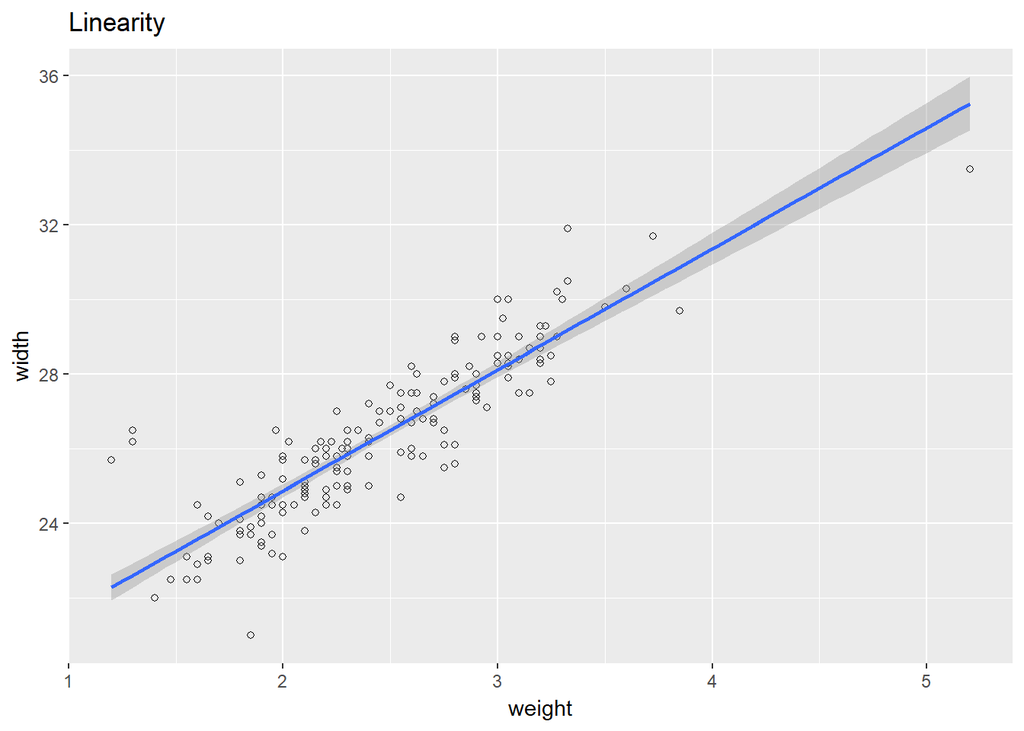

```r
# linearity between variables
ggplot(data = crab, aes(x = weight, y = width)) + geom_point(shape = 1) + geom_smooth(method = lm) + ggtitle('Linearity')
```

The boxplot shows **y** has considerable skewness when **color** is 2, 3 or 4.

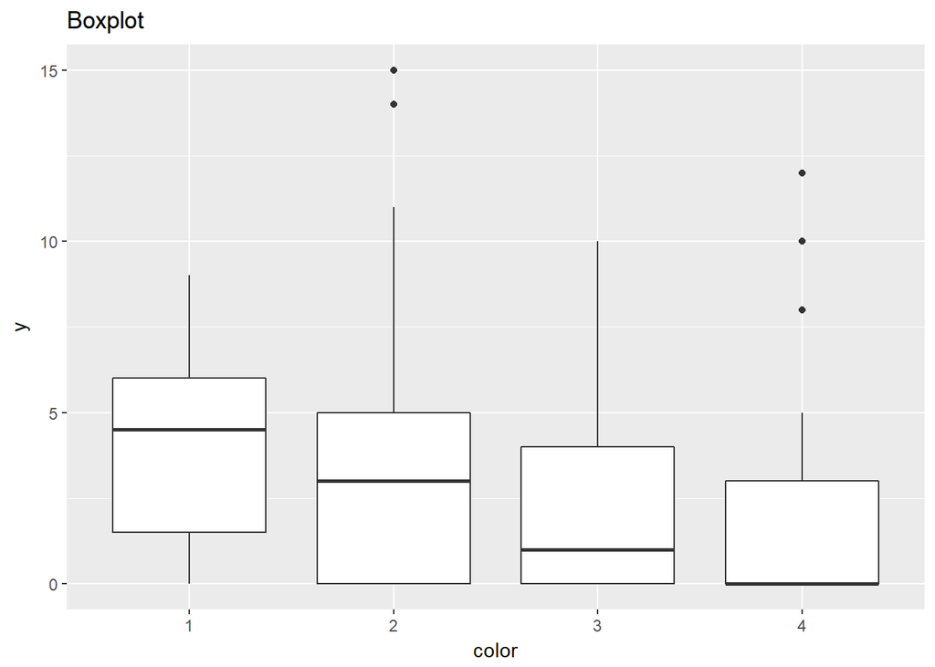

```r
# boxplot by color
ggplot(data = crab, aes(x = color, y = y))+geom_boxplot()+ggtitle('Boxplot')
```

The freqency plot verifies this idea.

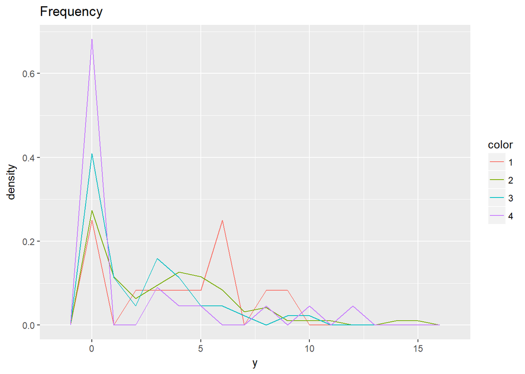

```r
# frequency plot
ggplot(data = crab, aes(x = y, y = ..density..))+geom_freqpoly(aes(colour = color),binwidth = 1)+ggtitle('Frequency')
```

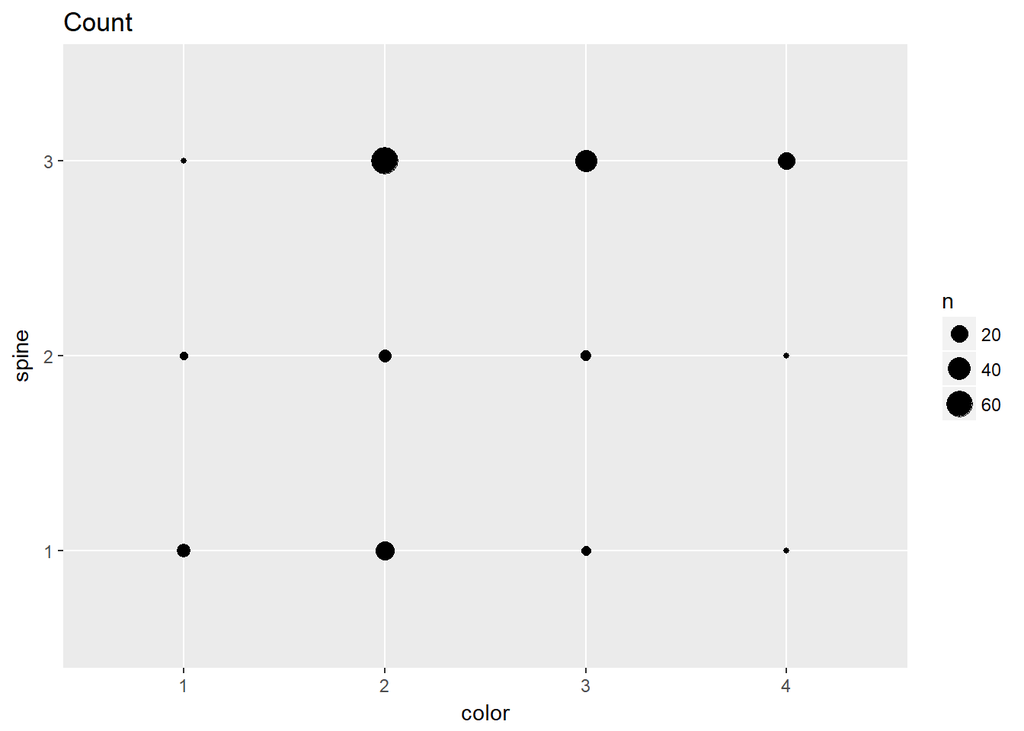

```r
# number of cases by color and spine
ggplot(data = crab, aes(x = color, y = spine)) + geom_count() + ggtitle('Count')
```

The scatter plot of MDS coordinates shows that points can be divided into 2 groups in a way.

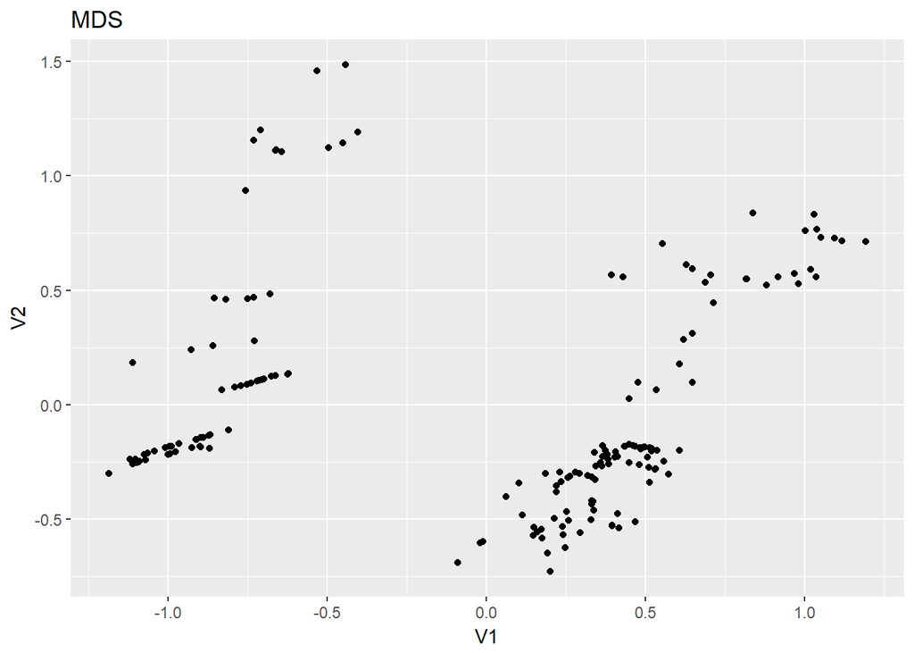

```r
# MDS plot
mds = cmdscale(dist(crab,method = 'canberra'))
mds = as.data.frame(mds)
ggplot(data = mds, aes(x = V1, y = V2)) + geom_point() + ggtitle('MDS')
```

### Conclusion

I will not use this dataset to do the final project. The main reason is that the data is relatively simple but I would like to do some challenging works. In addition, it is hard to get proper prior knowledge of crabs, so bayesian modeling may be not good for the data.